# Trying particle filtering on SIR model

```r
source("full_pomp_model.R")

library(foreach)
library(iterators)
library(dplyr)
library(ggplot2)
library(pomp)
```

We use the 2019 Clunes data here.  
We calculate conditional likelihood of SIR with no seasonal forcing at Aaron’s posterior parameter values (model 5). We take m, mj, mu and kappa (= 5000) as fixed, since these are more or less fixed from literature and Clunes usually has a population between 4000 and 6000 bats.

```r
pf <- replicate(5, pfilter(pomp_object, params = params, Np=2000))

ll <- sapply(pf,logLik)
logmeanexp(ll,se=TRUE)
```

```
                     se
-43.8419792   0.0116115
```

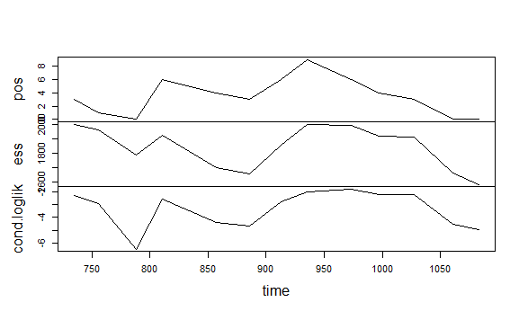

```r
plot(pf[[1]])
```

We set IF2 to estimate the parameters with 50 iterations and 3000 particles. We replicate it 10 times. Then we evaluate the log-likelihood at the result values with a particle filter.

```r
replicate( 10, mif2( pomp_object, params = model_5_params, Nmif=50, Np=3000,
     cooling.fraction.50=0.8,cooling.type="geometric",
     rw.sd=rw.sd(R0=0.02, gamma_val= 0.02, omega_m_val=0.02, zeta=0.02, c=0.02,
                 s=0.02, phi=0.02, disp=0.02, d=0.02)
)) -> mf1


# evaluate the log likelihood here
foreach(start = iter(mf1), .combine=rbind) %dopar% {replicate(5,
      start %>% pfilter() %>% logLik()
    ) %>%
      logmeanexp(se=TRUE) -> ll} -> ll_list


mf1_coef <- rbind(
  coef(mf1[[1]]), coef(mf1[[2]]), coef(mf1[[3]]), coef(mf1[[4]]), coef(mf1[[5]]),
  coef(mf1[[6]]), coef(mf1[[7]]), coef(mf1[[8]]), coef(mf1[[9]]), coef(mf1[[10]])
                  )
    data.frame(mf1_coef,loglik=ll_list[,1],loglik.se=ll_list[,2]) -> estimates

    estimates %>% select("loglik", "loglik.se","R0", "gamma_val",
                         "omega_m_val", "zeta", "c",
                          "s", "phi", "disp", "d")  %>% arrange(-loglik)
```

|  | loglik | loglik.se | R0 | gamma_val | omega_m_val | zeta | c | s | phi | disp | d |
| --- | --- | --- | --- | --- | --- | --- | --- | --- | --- | --- | --- |
| result.10 | -21.34759 | 0.002535518 | 10.58564 | 10.617883 | 6.275142 | 0.1564015 | 35.03721 | 204.46715 | 9.023383 | 1004.5274 | 8.059154 |
| result.8 | -21.66200 | 0.003945159 | 11.65008 | 10.218288 | 5.149564 | 0.2855903 | 23.35187 | 82.28902 | 5.854573 | 1205.2263 | 4.377174 |
| result.9 | -22.21016 | 0.003142568 | 11.05734 | 11.348489 | 4.689351 | 0.2976328 | 24.45900 | 114.70414 | 8.932613 | 662.5360 | 4.940914 |
| result.6 | -22.34152 | 0.001777327 | 10.82387 | 8.860996 | 5.116534 | 0.3001257 | 24.00718 | 139.19422 | 8.917109 | 1542.2774 | 3.847433 |
| result.5 | -22.50723 | 0.003820523 | 10.62325 | 9.702358 | 4.829709 | 0.2079529 | 19.93253 | 121.39976 | 8.900899 | 875.1711 | 6.407151 |
| result.4 | -22.69154 | 0.005197227 | 11.12693 | 8.352776 | 5.028593 | 0.3077142 | 19.10658 | 113.27458 | 8.893047 | 1126.1984 | 3.713071 |
| result.2 | -22.88087 | 0.002389656 | 10.55219 | 9.232874 | 4.642763 | 0.1972761 | 15.44404 | 83.63640 | 8.849704 | 805.5534 | 6.601532 |
| result.7 | -22.99313 | 0.003814176 | 11.22262 | 8.928274 | 4.402572 | 0.1339719 | 23.10124 | 192.37880 | 8.850790 | 875.4433 | 9.642474 |
| result.1 | -24.18261 | 0.005138285 | 10.12046 | 8.950167 | 5.016366 | 0.2064635 | 18.04913 | 114.14739 | 8.704935 | 716.0624 | 6.072860 |
| result.3 | -24.95345 | 0.002357016 | 11.86934 | 7.172786 | 4.162595 | 0.1474343 | 13.53274 | 109.74626 | 8.569005 | 669.7302 | 8.013820 |

```r
NA
```

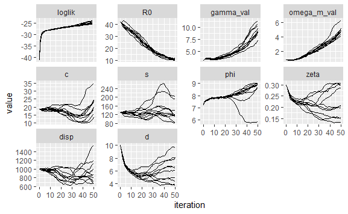

```r
foreach(start = iter(mf1)) %dopar% {
start %>%
  traces() %>%
  melt() %>%
  filter(variable %in% c("loglik","R0", "gamma_val", "omega_m_val", "zeta", "c",
                 "s", "phi", "disp", "d"))} -> filtered_plots

line_object = ggplot(NULL)
for (i in seq(1,10)){
line_object <- line_object +
                geom_line(data = filtered_plots[[i]], aes(x=iteration,y=value))
}
line_object+
facet_wrap(~variable, scales="free_y")+
guides(color=FALSE)
```

```r
NA
NA
```

```r
mean(estimates$R0)
```

```
[1] 10.96317
```

```r
mean(estimates$gamma_val)
```

```
[1] 9.338489
```

```r
mean(estimates$omega_m_val)
```

```
[1] 4.931319
```

Here we can see that R0 is around 11 in all the trajectories, gamma is certainly more than our starting value, and is around 9.33 on average, and also omega_m is higher, around 4.9 on average. The other values don’t seem to be converging.

```r
model_5_improved_params <- c(

  # base dynamics params
  model_type = 1, #  1: SIR, 2:SIRS or 3:SILI, matters for seasonal forcing only

  R0 =  10.58,
  gamma_val = 10.62, # recovery rate I -> R
  omega_val = 0, # immune waning rate R -> S
  omega_m_val = 6.27, # maternal antibody waning rate
  kappa_val = 5000, # carrying capacity for Clunes
  rho_val = 0, # I -> L
  epsilon_val = 0, # L -> I


  mu_val = 1.37, # juvenile maturation rate
  mj_val = 0.50, # juvenile death rate
  m_val = 0.23, # adult death rate
  delta_t = 365, # scaling time as days instead of years

  # seasonality params
  c = 35, # birth pulse scaling factor
  s = 204, # birth pulse synchronicity
  phi = 9.02, # birth pulse time shift

  c_v = 1, # seasonal drive scaling factor
  s_v = 0, # seasonal drive synchronicity
  phi_v = 0, # sesonal drive time shift

  # measuring process params
  zeta = 0.156, # test accuracy
  disp = 1004, # dispersion parameter
  d = 8 # number of bats contributing to the same pool



)
```

Now, to use the best new estimates for parameters as the starting values, I will need to calculate the new starting population equilibrium state with these parameters, and fit again to that to see if the likelihood actually improved when starting from the right state.

```r
model_5_improved_params <- c(

  # base dynamics params
  model_type = 1, #  1: SIR, 2:SIRS or 3:SILI, matters for seasonal forcing only

  R0 =  10.58,
  gamma_val = 10.62, # recovery rate I -> R
  omega_val = 0, # immune waning rate R -> S
  omega_m_val = 6.27, # maternal antibody waning rate
  kappa_val = 5000, # carrying capacity for Clunes
  rho_val = 0, # I -> L
  epsilon_val = 0, # L -> I


  mu_val = 1.37, # juvenile maturation rate
  mj_val = 0.50, # juvenile death rate
  m_val = 0.23, # adult death rate
  delta_t = 365, # scaling time as days instead of years

  # seasonality params
  c = 35, # birth pulse scaling factor
  s = 204, # birth pulse synchronicity
  phi = 9.02, # birth pulse time shift

  c_v = 1, # seasonal drive scaling factor
  s_v = 0, # seasonal drive synchronicity
  phi_v = 0, # sesonal drive time shift

  # measuring process params
  zeta = 0.156, # test accuracy
  disp = 1004, # dispersion parameter
  d = 8 # number of bats contributing to the same pool

)

pop_equ_pomp_model <- pomp(data=data.frame("time" = seq(1, 365*50)),
                              times="time",t0=0,
                              rprocess=discrete_time(step.fun=stochStep,delta.t=1),
                              rinit=model_5_before_equ_ini,
                              skeleton=map(det_model_skeleton, delta.t = 1),
                              statenames=state_names,
                              paramnames=param_names
 )

 pop_equ <- trajectory(pop_equ_pomp_model, params=model_5_improved_params,format="d")
 tail(pop_equ, 1)
```

|  | Ma | Sn | Sj | Sm | Sf | En | Ej | Em | Ef | In | Ij | Im | If | Rn | Rj | Rm | Rf | time | .id |
| --- | --- | --- | --- | --- | --- | --- | --- | --- | --- | --- | --- | --- | --- | --- | --- | --- | --- | --- | --- |
| 18250 | 43.85977 | 0.000745637 | 86.07332 | 10.7973 | 10.7973 | 0 | 0 | 0 | 0 | 0.006527465 | 46.28333 | 16.29531 | 16.29531 | 0.3953141 | 1230.827 | 2965.642 | 2965.642 | 18250 | 1 |

```r
NA
```

We set the initial states accordingly and recalculate the model:

```
$`1`

$`2`

$`3`

$`4`

attr(,"class")
[1] "list"      "ggarrange"
```

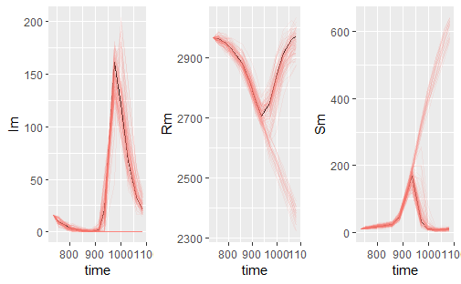

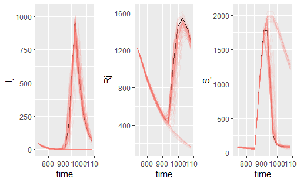

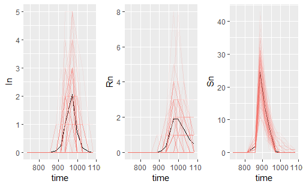

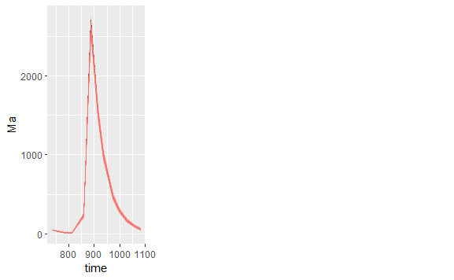

```r
   # 50 years waiting for equilibria
 model_5_improved_after_equ_ini <- Csnippet("

                        Ma = 43;
                        Sn = 0;
                        Sj = 86;
                        Sm = 11;
                        Sf = 11;

                        En = 0;
                        Ej = 0;
                        Em = 0;
                        Ef = 0;

                        In = 0;
                        Ij = 46;
                        Im = 16;
                        If = 16;

                        Rn = 0;
                        Rj = 1231;
                        Rm = 2965;
                        Rf = 2965;

                        ")
improved_pomp_object <- pomp(pomp_object, rinit = model_5_improved_after_equ_ini,
                             statenames = state_names)

sim <- simulate(improved_pomp_object,params=model_5_improved_params,format = "data.frame", nsim = 100)
x <- trajectory(improved_pomp_object,params=model_5_improved_params,format="d")


colnames(pos_dat) <-c("time", "true_pos")
sim_plus_data <- merge(sim, pos_dat, by.sim = "time")
sim_plus_data <- merge(sim_plus_data, samplesize_dat, by.sim_plus_data = "time")
sim_plus_data %>% mutate(true_test_prev = true_pos/samplesize, sim_test_prev = pos/samplesize,
                         sim_model_prev = (In + Ij + Im + If)/
                           (Sn + Sj + Sm + Sf + En + Ej +
                              Em + Ef + In + Ij + Im + If +
                              Rn + Rj + Rm + Rf + Ma)
) -> sim_plus_data



source("plots.R")
plots <- plots(sim_plus_data, x, sim)
names(plots) <- c(   "plIm", "plRm", "plSm",
                     "plIj", "plRj", "plSj",
                     "plIn", "plRn", "plSn",
                     "plMa")


# plotting prevalence from tests and actual from the model

ggplot(NULL)+
  geom_line(data=sim_plus_data, alpha = 0.1,aes(x=time, y = sim_model_prev, group= factor(.id), colour = "Simulated model prevalence"
  ))+
  geom_line(data=sim_plus_data, alpha = 0.1,aes(x=time, y = true_test_prev, group= factor(.id), colour = "2019 Clunes underroost prevalence"
  ))+
  geom_line(data=sim_plus_data, alpha = 0.1,aes(x=time, y = sim_test_prev, group= factor(.id), colour = "Simulated underroost prevalence"
  ))->plprev

ggarrange(plotlist = plots, ncol = 3)
```

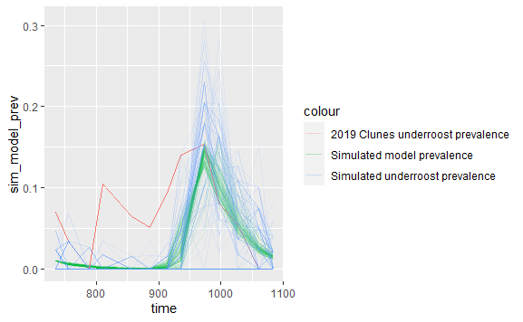

```r
plot(plprev)
```

```r
NA
NA
```

```r
pf <- replicate(5, pfilter(improved_pomp_object, params = model_5_improved_params, Np=2000))

ll <- sapply(pf,logLik)
logmeanexp(ll,se=TRUE)
```

```
                     se
-57.1799288   0.1327322
```

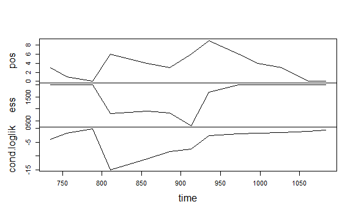

```r
plot(pf[[1]])
```

Now even if this approach doesnt seem to be working, lets try iterated filtering again as I’m just curious if there is some convergence this time.

|  | loglik | loglik.se | R0 | gamma_val | omega_m_val | zeta | c | s | phi | disp | d |
| --- | --- | --- | --- | --- | --- | --- | --- | --- | --- | --- | --- |
| result.4 | -24.03563 | 0.007361723 | 12.920416 | 11.009168 | 4.620739 | 0.3205017 | 11.596975 | 308.90233 | 8.027690 | 498.5549 | 22.49288 |
| result.9 | -24.11457 | 0.007481664 | 12.664762 | 11.484812 | 4.295429 | 0.3746644 | 13.858121 | 380.80429 | 8.019732 | 1327.0025 | 19.37048 |
| result.2 | -24.14887 | 0.009052344 | 17.072711 | 8.515516 | 5.477451 | 0.2212463 | 10.086312 | 447.38453 | 8.072617 | 1762.0402 | 29.01084 |
| result.8 | -24.23431 | 0.003210703 | 16.973164 | 9.560922 | 4.368002 | 0.3025430 | 8.898751 | 245.66181 | 8.062517 | 539.4875 | 22.11612 |
| result.10 | -24.44350 | 0.012663201 | 8.882092 | 12.182717 | 5.839879 | 0.3861045 | 13.831575 | 226.50678 | 7.972665 | 929.3467 | 17.98477 |
| result.6 | -24.65922 | 0.017652795 | 11.096398 | 11.150560 | 5.446634 | 0.3331584 | 11.137656 | 220.37555 | 8.000814 | 1035.8983 | 21.94285 |
| result.1 | -25.83141 | 0.013631886 | 12.319384 | 11.259626 | 2.889036 | 0.2319141 | 14.295288 | 138.90506 | 7.988583 | 1496.2925 | 24.42655 |
| result.7 | -27.52373 | 0.030737404 | 10.121427 | 13.175734 | 3.058269 | 0.3285758 | 16.822445 | 129.05894 | 7.980736 | 652.7324 | 18.89780 |
| result.3 | -49.75614 | 0.077183480 | 23.527464 | 22.943877 | 4.879359 | 0.3049492 | 19.141935 | 88.11059 | 59.118572 | 1702.6299 | 11.62572 |
| result.5 | -109.47375 | 0.269046981 | 24.164414 | 17.525519 | 5.854906 | 0.2776665 | 17.604560 | 224.69189 | 54.693973 | 1024.6010 | 12.74768 |

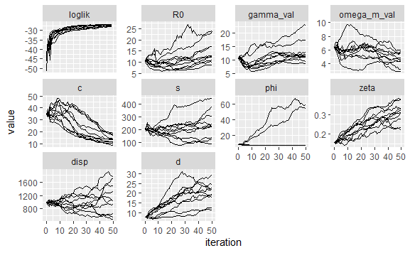

```r
foreach(start = iter(mf)) %dopar% {
start %>%
  traces() %>%
  melt() %>%
  filter(variable %in% c("loglik","R0", "gamma_val", "omega_m_val", "zeta", "c",
                 "s", "phi", "disp", "d"))} -> filtered_plots

line_object = ggplot(NULL)
for (i in seq(1,10)){
line_object <- line_object +
                geom_line(data = filtered_plots[[i]], aes(x=iteration,y=value))
}
line_object+
facet_wrap(~variable, scales="free_y")+
guides(color=FALSE)
```

```r
NA
NA
```

So indeed we see that this method is not really working well. I need to figure out how to do this so that the initial popultion equlibria do not mess things up.